# Alzamora_Data_Project_1

Carter Alzamora

2025-03-11

## Exploratory Data Analysis

### Continuous

- **Age (Age)**: Age in years
- **Resting Blood Pressure (RestBP)**: Resting blood pressure (in mm Hg on admission to the hospital)
- **Cholesterol (Chol)**: Serum cholestoral in mg/dl
- **Maximum Heart Rate (MaxHR)**: Maximum heart rate achieved in beats per minute
- **Exercise ST Depression (Oldpeak)**: ST depression induced by exercise relative to rest

## Predictor Variable Quantification

The predictor variables are summarized below with their class balances being shown in **Table 1**. The distribution the categorical variables as well as their correlation with AHD is shown in **Figure 1** while the distributions of the continuous variables split between each response category is shown in **Figure 2**.

**A**

|  | Age | RestBP | Chol | MaxHR | Oldpeak |
| --- | --- | --- | --- | --- | --- |
|  | Min. :29.00 | Min. : 94.0 | Min. :126.0 | Min. : 71.0 | Min. :0.000 |
|  | 1st Qu.:48.00 | 1st Qu.:120.0 | 1st Qu.:211.0 | 1st Qu.:133.0 | 1st Qu.:0.000 |
|  | Median :56.00 | Median :130.0 | Median :243.0 | Median :153.0 | Median :0.800 |
|  | Mean :54.54 | Mean :131.7 | Mean :247.4 | Mean :149.6 | Mean :1.056 |
|  | 3rd Qu.:61.00 | 3rd Qu.:140.0 | 3rd Qu.:276.0 | 3rd Qu.:166.0 | 3rd Qu.:1.600 |
|  | Max. :77.00 | Max. :200.0 | Max. :564.0 | Max. :202.0 | Max. :6.200 |

**B**

|  | Sex | Fbs | ExAng | AHD |
| --- | --- | --- | --- | --- |
|  | male : 96 | No :254 | No :200 | Yes:137 |
|  | female:201 | Yes: 43 | Yes: 97 | No :160 |

|  | RestECG | Slope | Thal | ChestPain | Ca |
| --- | --- | --- | --- | --- | --- |
|  | normal :147 | upsloping :139 | fixed : 18 | typical : 23 | 0:174 |
|  | wave abnormality: 4 | flat :137 | normal :164 | nontypical : 49 | 1: 65 |
|  | hypertrophy :146 | downsloping: 21 | reversable:115 | nonanginal : 83 | 2: 38 |
|  |  |  |  | asymptomatic:142 | 3: 20 |

**Table 1.** Summary Statistics for all continuous (A) and categorical (B) variables.

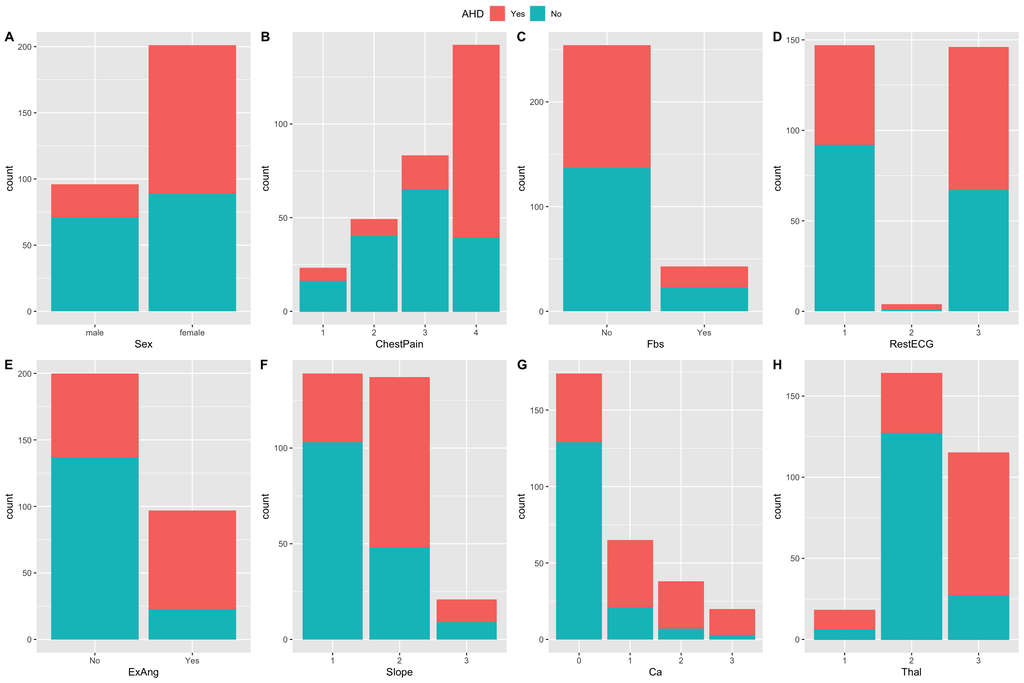

**Figure 1:** Categorical variable class balance and correlation with the proportion of diagnosed AHD

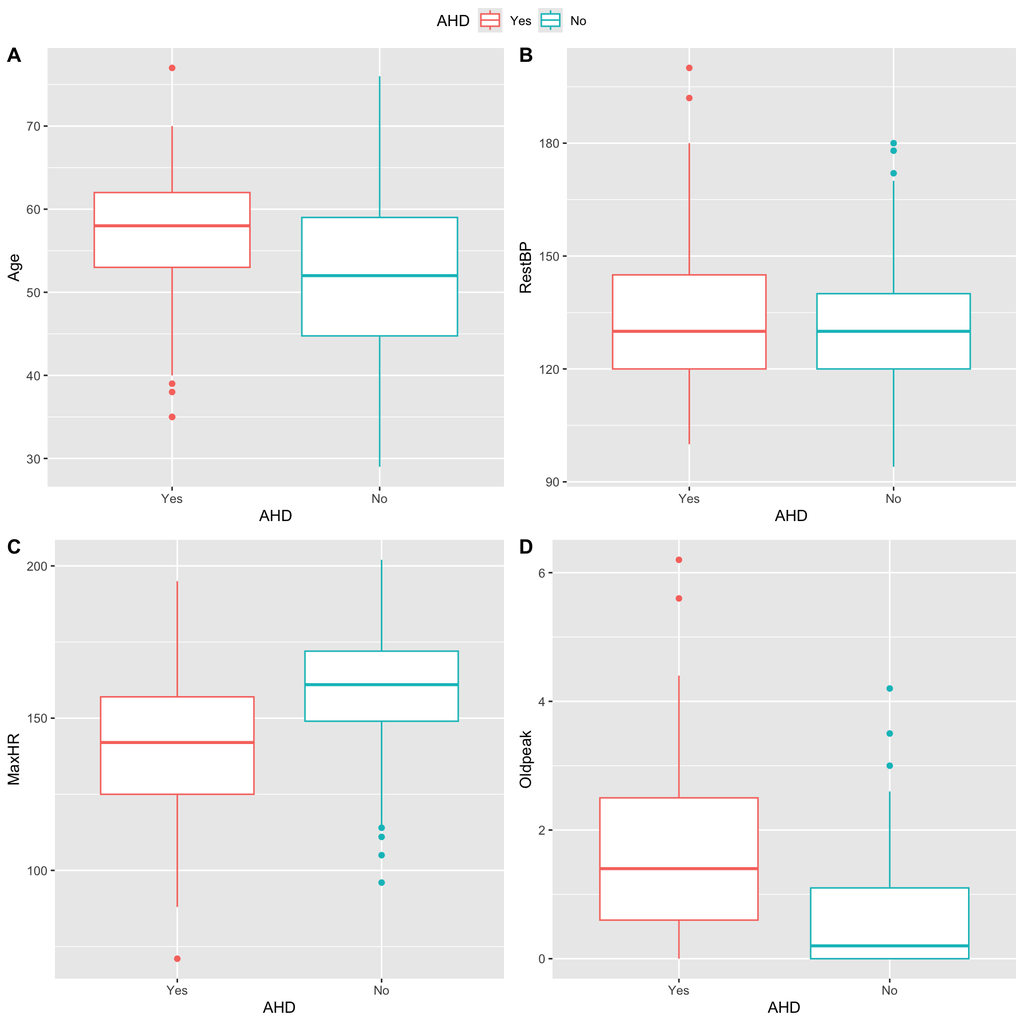

**Figure 2:** Continuous variable correlation with the diagnosis of heart disease (AHD).

## Model Selection:

### Random Forest

**Features**:  
- can handle categorical response with 2 or more levels  
- can handle quantitative AND categorical predictors

**Assumptions**:  
- Independent Observations

### SVM

**Features**:  
- can handle categorical response with 2 or more levels  
- can handle highly dimensional data sets

**Assumptions**:  
- Independent Observations  
- 2 categorical response variables

### Logistic Regression

**Features**:  
- can handle categorical response with 2 levels  
- can handle quantitative AND categorical predictors

**Assumptions**:  
- Independent Observations  
- Response follows binomial distribution

### Assumptions:

The independence assumption is violated, this can be seen in **Figure 3** showing the correlated relationship between the quantitative variables. However, because the response variable is categorical and binary (YES or NO), the distribution will be binomial so the binomial distribution assumption for SVM and Logistic Regression is true.

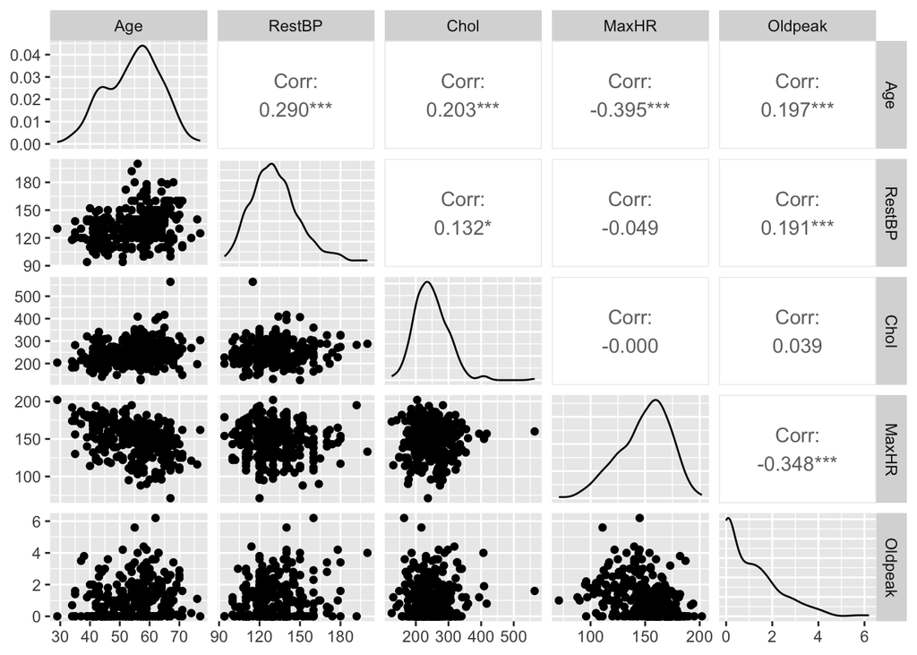

**Figure 3:** ggpairs of all continuous variables showing relationship between variables.

## Compare Models:

**Training data**: 80%  
**Testing data:** 20%  
The models were trained using a consistent workflow and cross validation method in order to compare accuracy and costs. The class balance of these two data sets are shown in **Table 2**.

**A**

|  | AHD |
| --- | --- |
|  | Yes:109 |
|  | No :128 |

**B**

|  | AHD |
| --- | --- |
|  | Yes:28 |
|  | No :32 |

**Table 2:** Class balance of the training(A) and testing(B) data set

### Plot Model Accuracies with Training Data

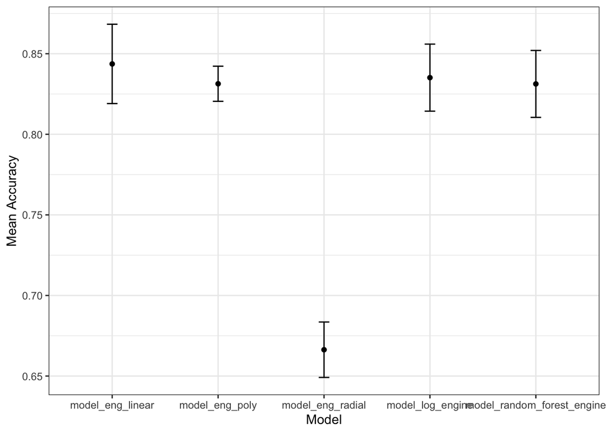

All models except for the radial SVM engine perform similarly, with the linear SMV engine slightly out performing the other models. However, the standard error bars show that the random forest, logistic regression, poly SMV engine, are well within the same accuracy range while the radial SVM engine is drastically lower accuracy than all other models.

### Confusion Matricies

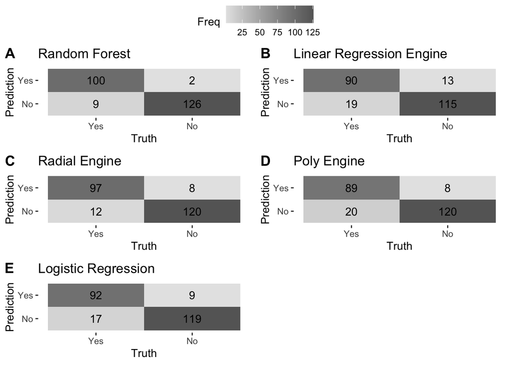

### ROC curves to TEST data

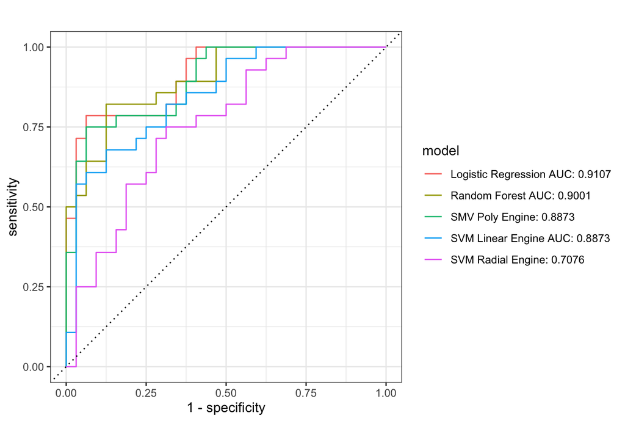

**Figure 6.** ROC curves including AUC value of the best of all models after cross validation applied to testing data.

Each model was cross validated and applied to the testing data. The AUC values were calculated in order to show the performance of the model (**Figure 6**). Logistic Regression slightly outperforms the other models with random forest being the second best.

## Model Choice

I would recommend the **Random Forest** model. Random Forest is shown to match the other models in accuracy **(Figure 4)**, and out compete the other models by far for class error rates **(Figure 5)**. Although it is slightly out competed in AUC values when merged with the testing data as shown in **Figure 6**, it is a close second, being only ~.01 lower than logistic regression.